# examples_day06

For each of the patterns below, determine the Frieze group.

## Pattern 1

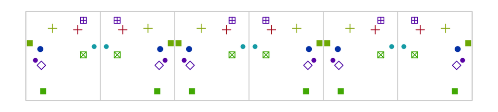

Frieze group:

## Pattern 2

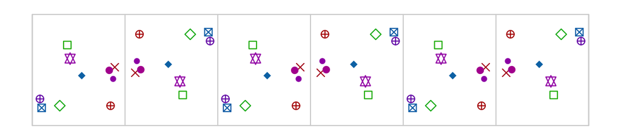

Frieze group:

## Pattern 3

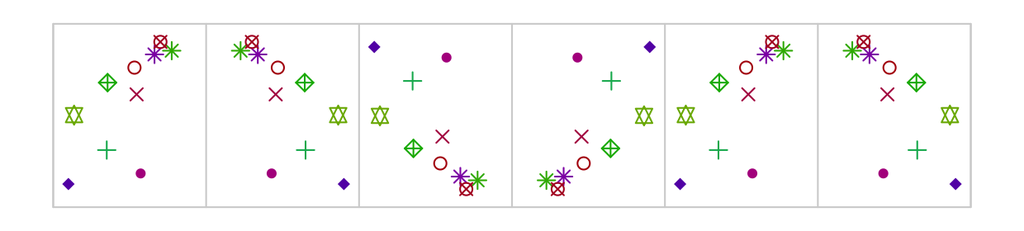

Frieze group:

## Pattern 4

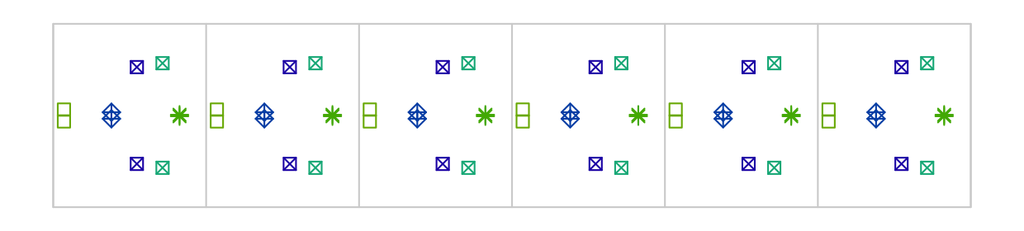

Frieze group:

## Pattern 5

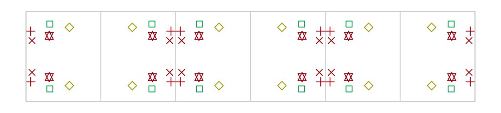

Frieze group:

## Pattern 6

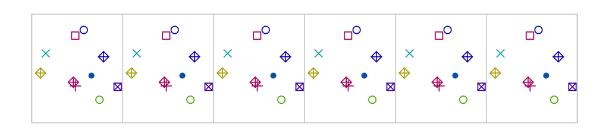

Frieze group:

## Pattern 7

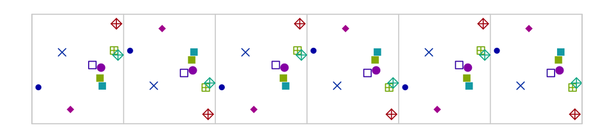

Frieze group:

- The first pattern is a p1m1 (sidle).
- The second pattern is a p2 (spinning hop).
- The third pattern is a p2mg (spinning sidle).
- The fourth pattern is a p11m (jump).
- The fifth pattern is a p2mm (spinning jump).
- The sixth pattern is a p1 (hop).
- The seventh pattern is a p11g (step).

For each of the patterns below, determine the Frieze group.

## Pattern 1

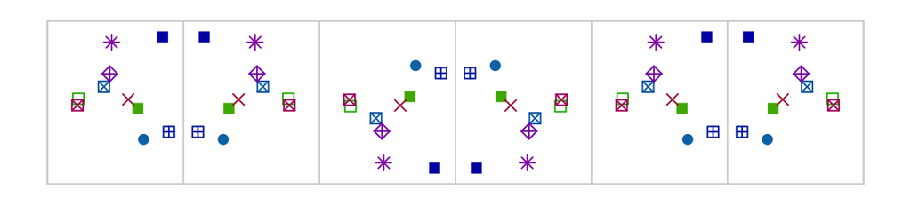

Frieze group:

## Pattern 2

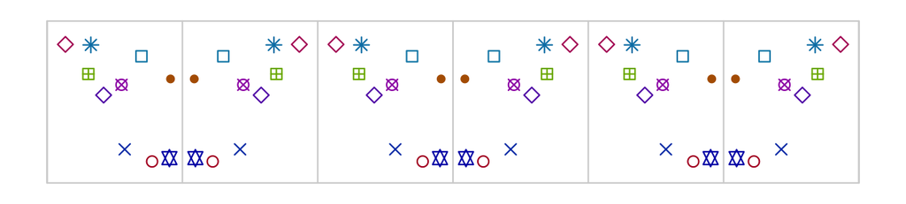

Frieze group:

## Pattern 3

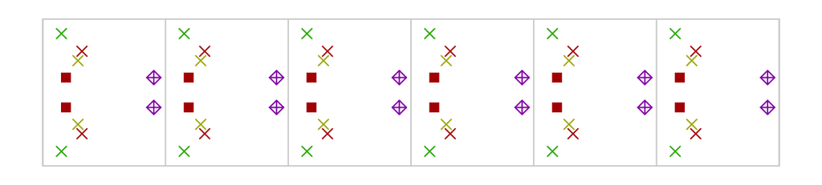

Frieze group:

## Pattern 4

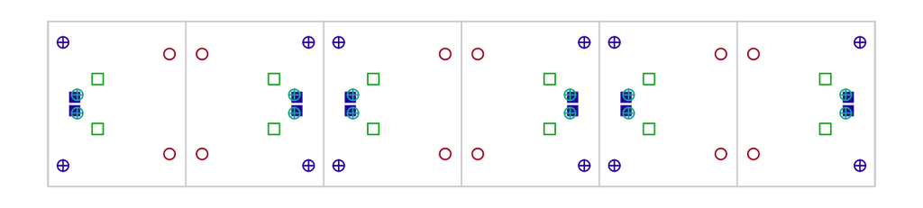

Frieze group:

## Pattern 5

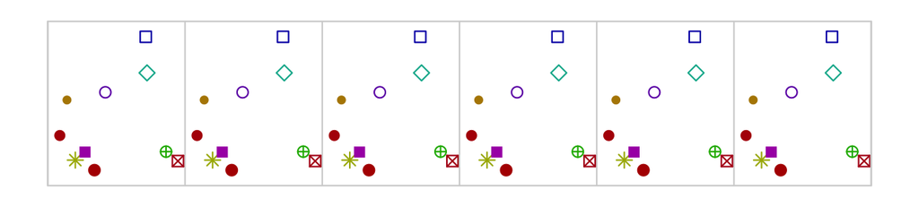

Frieze group:

## Pattern 6

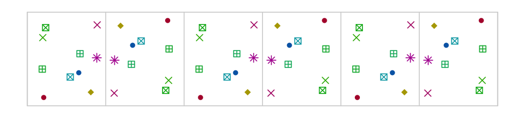

Frieze group:

## Pattern 7

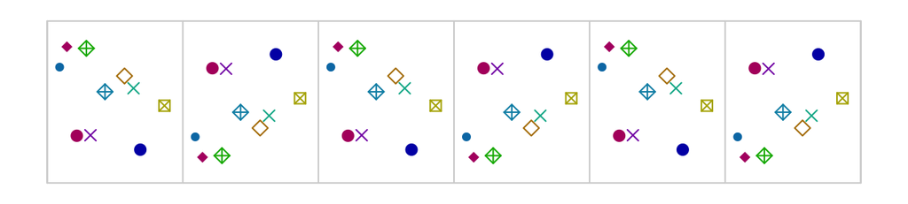

Frieze group:

- The first pattern is a p2mg (spinning sidle).
- The second pattern is a p1m1 (sidle).
- The third pattern is a p11m (jump).
- The fourth pattern is a p2mm (spinning jump).
- The fifth pattern is a p1 (hop).
- The sixth pattern is a p2 (spinning hop).
- The seventh pattern is a p11g (step).

For each of the patterns below, determine the Frieze group.

## Pattern 1

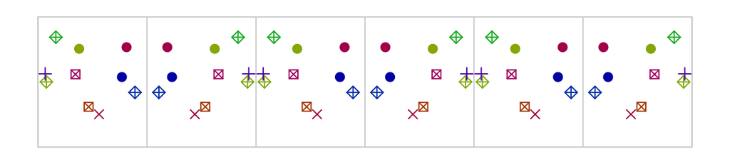

Frieze group:

## Pattern 2

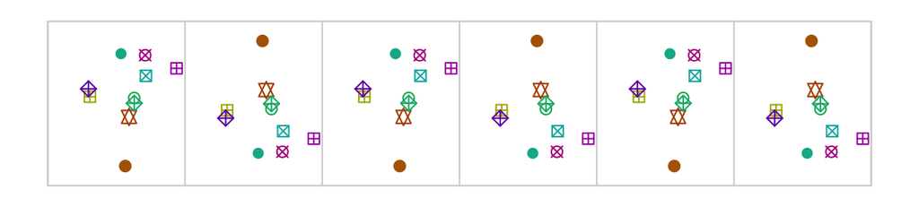

Frieze group:

## Pattern 3

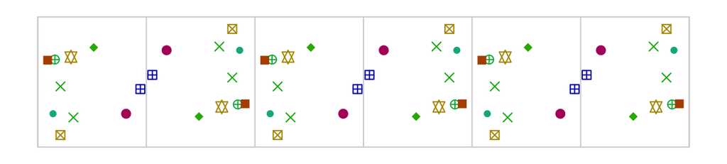

Frieze group:

## Pattern 4

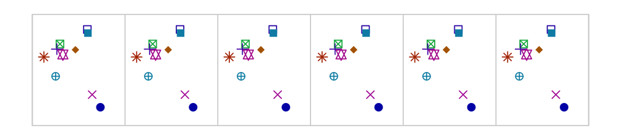

Frieze group:

## Pattern 5

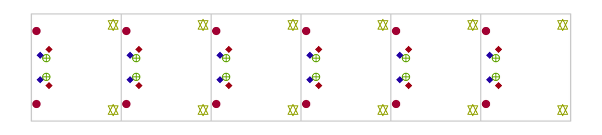

Frieze group:

## Pattern 6

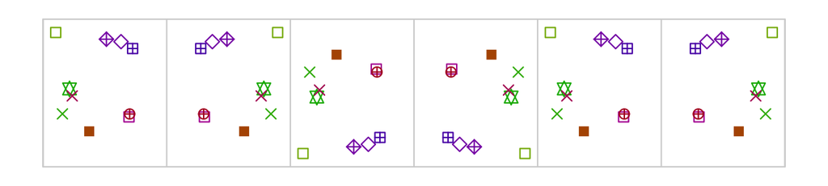

Frieze group:

## Pattern 7

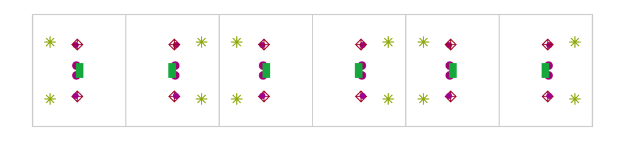

Frieze group:

- The first pattern is a p1m1 (sidle).
- The second pattern is a p11g (step).
- The third pattern is a p2 (spinning hop).
- The fourth pattern is a p1 (hop).
- The fifth pattern is a p11m (jump).
- The sixth pattern is a p2mg (spinning sidle).
- The seventh pattern is a p2mm (spinning jump).

For each of the patterns below, determine the Frieze group.

## Pattern 1

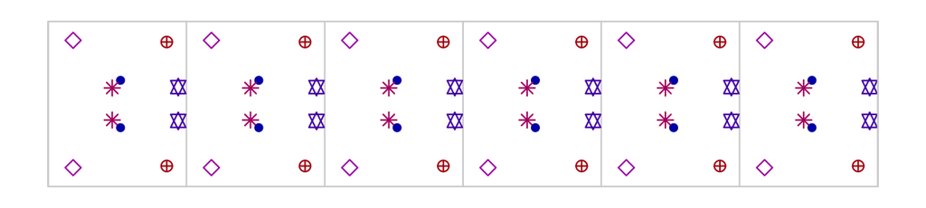

Frieze group:

## Pattern 2

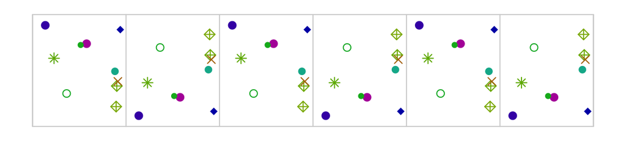

Frieze group:

## Pattern 3

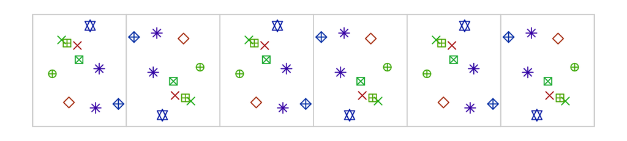

Frieze group:

## Pattern 4

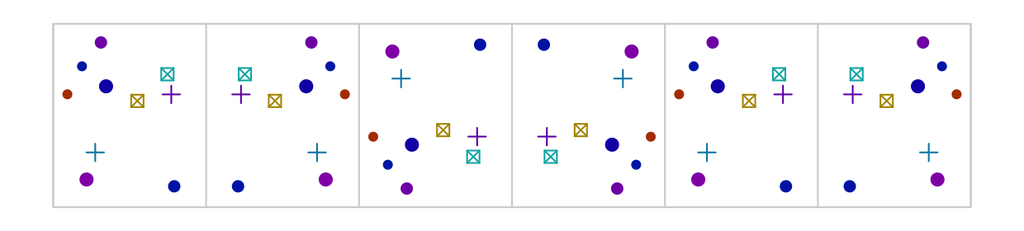

Frieze group:

## Pattern 5

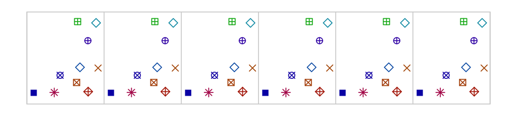

Frieze group:

## Pattern 6

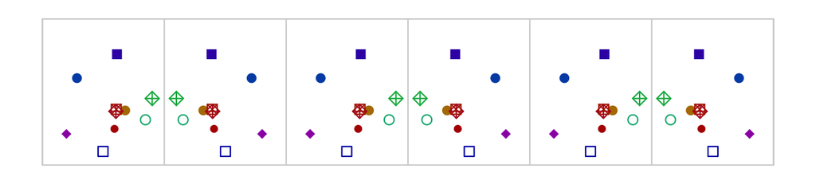

Frieze group:

## Pattern 7

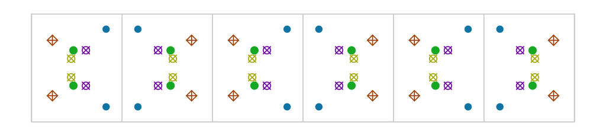

Frieze group:

- The first pattern is a p11m (jump).
- The second pattern is a p11g (step).
- The third pattern is a p2 (spinning hop).
- The fourth pattern is a p2mg (spinning sidle).
- The fifth pattern is a p1 (hop).
- The sixth pattern is a p1m1 (sidle).
- The seventh pattern is a p2mm (spinning jump).

For each of the patterns below, determine the Frieze group.